# Anlysis of Museum Collection

## Dataset and Motivation

- Out dataset is [The Metropolitan Museum of Art Open Access](https://github.com/metmuseum/openaccess/) in CSV format. The Metropolitan Museum of Art has waived all copyright and related or neighboring rights to this dataset to inspire more researchers exploring it.
- This dataset include identifying data of more than 470,000 artworks in the museum collection. It provides detailed information of each artworks, which reveal huge potential of data analyzing work.
- At the same time, the meta data is full of data cleaning problems, such as the data was put in the wrong places, missing values, missing documentation, inconsistent information, possible duplication, mixed text and numeric data. It is a really good dataset for practicing data cleaning work.

The main attributes of the dataset are:

- **Object Number/Object ID**: a unique number sequence for each object in museum.
- **Is Highlight**: a bool to show whether an object is highlighted or not.
- **Is Public domain**: a bool to show whether an object is displayed in public domain or not.
- **Department**: the department the object belongs to.
- **Object name**: how the object called.
- **Title**: detailed object name with discription.
- **Culture/Period/Dynasty/Reign**: the background of each object.
- **Portfolio**: the portfolio the object belongs to.
- **Artist Pole/Artist Prefix/Artist Display Name/Artist Display Bio/Artist Suffix/Artist Alpha Sort/Artist Nationality/Artist Begin Date/Artist End Date**: all detailed artist background.
- **Object Date/Object Begin Date/Object End Date**: the display period of each object.
- **Medium**: the materials used to make the items.
- **Dimensions**: the dimension of each object.
- **Credit Line**: the credit information of each object.
- **Classification**: the category of material each objects belongs to.

## Research Questions

We are interested in the distribution of all the collections, which could be analyzed by storing departments, collection types, credit line history and roles of artist.

- The objects and corresponding departments
  - Input: Department name extracted from the Department column.
  - Output: A visual check of the number of artworks in each department.
- The objects and corresponding types
  - Input: Object type extracted from the Object_Name column. This column only contains object type. The detailed discription is stored in Object_Title.
  - Output: A visual check of several top amount of artworks' types that are collected in the museum.
- The objects and corresponding credit line
  - Input: Credit year extracted from the Credit_Line column.
  - Output: A visual check of the credit line frequency in the history by time line.
- The artist roles
  - Input: Artist roled extracted from the Artist_Role column.
  - Output: A visual check of most popular roles who produced masterpieces in history.

## Literature Reviews

Here is an article about analyzing the same museum collection: [When art meets big data: Analyzing 200,000 items from The Met collection in BigQuery](https://cloud.google.com/blog/products/gcp/when-art-meets-big-data-analyzing-200000-items-from-the-met-collection-in-bigquery).The author use SQL to start the analysis.

**Common idea**

```
Both of us analyze the artworks' distribution by department.
```

**Different insights**

```
The author find the the materials used to make the items in the Medium column are all comma-separated string. So he visualize the materials' frequency to see what is the most commonly used meterial for artworks in the history of The Metropolitan Museum of Art. Based on this, the result grouped by the history period is implemented. Also the author gives the collection categoried by the color of objects with webscrapping from the url link of each object.

We are more focused on the distribution patterns with the timeline rather than period. The frequency in the credit line of history is visualized. But the group by method is inspiring, we should throw our light on that.
```

## Data cleaning

This data cleaning section is intended to clean the dataset rather than formating the dataset. So in case of losing raw information, we intend to store the cleaned data into new columns and preserve the raw data.

### Import all the module required

```python
import pandas as pd
import numpy as np
import re
import seaborn as sns
import matplotlib.pyplot as plt
%matplotlib inline
import nltk
from collections import Counter, defaultdict
from nltk.stem import WordNetLemmatizer
from nltk.corpus import wordnet
from wordcloud import WordCloud
from math import inf
import data_clean_functions as dcf
```

### Import the data from the website

```python
collection_df = pd.read_csv("https://media.githubusercontent.com/media/metmuseum/openaccess/master/MetObjects.csv")
```

In original columns, some column names have space in it, which could be difficult to call. So we modify the names of columns for indexing convenience.

```python
collection_df.columns = ['_'.join(col_name.split()) for col_name in collection_df]
```

### First look of the data

```python
collection_df.dtypes
```

```
Object_Number              object
Is_Highlight                 bool
Is_Public_Domain             bool
Object_ID                   int64
Department                 object
Object_Name                object
Title                      object
Culture                    object
Period                     object
Dynasty                    object
Reign                      object
Portfolio                  object
Artist_Role                object
Artist_Prefix              object
Artist_Display_Name        object
Artist_Display_Bio         object
Artist_Suffix              object
Artist_Alpha_Sort          object
Artist_Nationality         object
Artist_Begin_Date          object
Artist_End_Date            object
Object_Date                object
Object_Begin_Date           int64
Object_End_Date             int64
Medium                     object
Dimensions                 object
Credit_Line                object
Geography_Type             object
City                       object
State                      object
County                     object
Country                    object
Region                     object
Subregion                  object
Locale                     object
Locus                      object
Excavation                 object
River                      object
Classification             object
Rights_and_Reproduction    object
Link_Resource              object
Metadata_Date              object
Repository                 object
Tags                       object
dtype: object
```

We could check number of NaNs in all the columns first and try to ignore those columns whose most values are NaN. Those columns almost filled with contents are more likely to give us general patterns of the dataset, which should be analyzed prior. These kind of columns include Object_Number, Is_Highlight, Is_Public_Domain, Object_ID, Department, Object_Name and etc.

We give a practical example of dropping all the columns whose NaN values are more than 10%. But we won't use this for practicing perpose.

```python
collection_df.isna().sum()
```

```
Object_Number                   0
Is_Highlight                    0
Is_Public_Domain                0
Object_ID                       0
Department                      0
Object_Name                  4393
Title                       31068
Culture                    283671
Period                     403133
Dynasty                    469324
Reign                      481403
Portfolio                  470591
Artist_Role                208697
Artist_Prefix              394553
Artist_Display_Name        206607
Artist_Display_Bio         255496
Artist_Suffix              480885
Artist_Alpha_Sort          206642
Artist_Nationality         299162
Artist_Begin_Date          253058
Artist_End_Date            255845
Object_Date                 15033
Object_Begin_Date               0
Object_End_Date                 0
Medium                       7629
Dimensions                  76560
Credit_Line                   705
Geography_Type             432304
City                       460434
State                      489805
County                     484040
Country                    415861
Region                     460634
Subregion                  470331
Locale                     477045
Locus                      485277
Excavation                 476642
River                      490510
Classification              56479
Rights_and_Reproduction    467829
Link_Resource                   0
Metadata_Date                   0
Repository                      0
Tags                       214342
dtype: int64
```

```python
filtered_df =  collection_df.loc[:, collection_df.isna().sum(axis = 0) < len(collection_df.index)*0.1 ]
filtered_df
```

|  | Object_Number | Is_Highlight | Is_Public_Domain | Object_ID | Department | Object_Name | Title | Object_Date | Object_Begin_Date | Object_End_Date | Medium | Credit_Line | Link_Resource | Metadata_Date | Repository |
| --- | --- | --- | --- | --- | --- | --- | --- | --- | --- | --- | --- | --- | --- | --- | --- |
| 0 | 1979.486.1 | False | False | 1 | American Decorative Arts | Coin | One-dollar Liberty Head Coin | 1853 | 1853 | 1853 | Gold | Gift of Heinz L. Stoppelmann, 1979 | http://www.metmuseum.org/art/collection/search/1 | 3/18/2019 8:00:01 AM | Metropolitan Museum of Art, New York, NY |
| 1 | 1980.264.5 | False | False | 2 | American Decorative Arts | Coin | Ten-dollar Liberty Head Coin | 1901 | 1901 | 1901 | Gold | Gift of Heinz L. Stoppelmann, 1980 | http://www.metmuseum.org/art/collection/search/2 | 3/18/2019 8:00:01 AM | Metropolitan Museum of Art, New York, NY |
| 2 | 67.265.9 | False | False | 3 | American Decorative Arts | Coin | Two-and-a-Half Dollar Coin | 1909–27 | 1909 | 1927 | Gold | Gift of C. Ruxton Love, Jr., 1967 | http://www.metmuseum.org/art/collection/search/3 | 3/18/2019 8:00:01 AM | Metropolitan Museum of Art, New York, NY |
| 3 | 67.265.10 | False | False | 4 | American Decorative Arts | Coin | Two-and-a-Half Dollar Coin | 1909–27 | 1909 | 1927 | Gold | Gift of C. Ruxton Love, Jr., 1967 | http://www.metmuseum.org/art/collection/search/4 | 3/18/2019 8:00:01 AM | Metropolitan Museum of Art, New York, NY |
| 4 | 67.265.11 | False | False | 5 | American Decorative Arts | Coin | Two-and-a-Half Dollar Coin | 1909–27 | 1909 | 1927 | Gold | Gift of C. Ruxton Love, Jr., 1967 | http://www.metmuseum.org/art/collection/search/5 | 3/18/2019 8:00:01 AM | Metropolitan Museum of Art, New York, NY |
| 5 | 67.265.12 | False | False | 6 | American Decorative Arts | Coin | Two-and-a-Half Dollar Coin | 1909–27 | 1909 | 1927 | Gold | Gift of C. Ruxton Love, Jr., 1967 | http://www.metmuseum.org/art/collection/search/6 | 3/18/2019 8:00:01 AM | Metropolitan Museum of Art, New York, NY |
| 6 | 67.265.13 | False | False | 7 | American Decorative Arts | Coin | Two-and-a-Half Dollar Coin | 1909–27 | 1909 | 1927 | Gold | Gift of C. Ruxton Love, Jr., 1967 | http://www.metmuseum.org/art/collection/search/7 | 3/18/2019 8:00:01 AM | Metropolitan Museum of Art, New York, NY |
| 7 | 67.265.14 | False | False | 8 | American Decorative Arts | Coin | Two-and-a-Half Dollar Coin | 1909–27 | 1909 | 1927 | Gold | Gift of C. Ruxton Love, Jr., 1967 | http://www.metmuseum.org/art/collection/search/8 | 3/18/2019 8:00:01 AM | Metropolitan Museum of Art, New York, NY |
| 8 | 67.265.15 | False | False | 9 | American Decorative Arts | Coin | Two-and-a-Half Dollar Coin | 1909–27 | 1909 | 1927 | Gold | Gift of C. Ruxton Love, Jr., 1967 | http://www.metmuseum.org/art/collection/search/9 | 3/18/2019 8:00:01 AM | Metropolitan Museum of Art, New York, NY |
| 9 | 1979.486.3 | False | False | 10 | American Decorative Arts | Coin | Two-and-a-half-dollar Indian Head Coin | 1912 | 1912 | 1912 | Gold | Gift of Heinz L. Stoppelmann, 1979 | http://www.metmuseum.org/art/collection/search/10 | 3/18/2019 8:00:01 AM | Metropolitan Museum of Art, New York, NY |
| 10 | 1979.486.2 | False | False | 11 | American Decorative Arts | Coin | Two-and-a-half-dollar Liberty Head Coin | 1907 | 1907 | 1907 | Gold | Gift of Heinz L. Stoppelmann, 1979 | http://www.metmuseum.org/art/collection/search/11 | 3/18/2019 8:00:01 AM | Metropolitan Museum of Art, New York, NY |
| 11 | 1979.486.7 | False | False | 12 | American Decorative Arts | Coin | Twenty-dollar Liberty Head Coin | 1876 | 1876 | 1876 | Gold | Gift of Heinz L. Stoppelmann, 1979 | http://www.metmuseum.org/art/collection/search/12 | 3/18/2019 8:00:01 AM | Metropolitan Museum of Art, New York, NY |
| 12 | 1979.486.4 | False | False | 13 | American Decorative Arts | Coin | Five-dollar Indian Head Coin | 1910 | 1910 | 1910 | Gold | Gift of Heinz L. Stoppelmann, 1979 | http://www.metmuseum.org/art/collection/search/13 | 3/18/2019 8:00:01 AM | Metropolitan Museum of Art, New York, NY |
| 13 | 1979.486.5 | False | False | 14 | American Decorative Arts | Coin | Five-dollar Liberty Head Coin | 1907 | 1907 | 1907 | Gold | Gift of Heinz L. Stoppelmann, 1979 | http://www.metmuseum.org/art/collection/search/14 | 3/18/2019 8:00:01 AM | Metropolitan Museum of Art, New York, NY |
| 14 | 16.74.49 | False | False | 15 | American Decorative Arts | Coin | Coin, 1/2 Real | 1665–1700 | 1665 | 1700 | Silver | Gift of Mrs. Russell Sage, 1916 | http://www.metmuseum.org/art/collection/search/15 | 3/18/2019 8:00:01 AM | Metropolitan Museum of Art, New York, NY |
| 15 | 16.74.27 | False | False | 16 | American Decorative Arts | Peso | Coin, 1/4 Peso | 1800–1900 | 1800 | 1900 | Bronze or copper | Gift of Mrs. Russell Sage, 1916 | http://www.metmuseum.org/art/collection/search/16 | 3/18/2019 8:00:01 AM | Metropolitan Museum of Art, New York, NY |
| 16 | 16.74.28 | False | False | 17 | American Decorative Arts | Peso | Coin, 1/4 Peso | 1867 | 1867 | 1867 | Bronze or copper | Gift of Mrs. Russell Sage, 1916 | http://www.metmuseum.org/art/collection/search/17 | 3/18/2019 8:00:01 AM | Metropolitan Museum of Art, New York, NY |
| 17 | 16.74.29 | False | False | 18 | American Decorative Arts | Peso | Coin, 1/4 Peso | 1860 | 1860 | 1860 | Bronze or copper | Gift of Mrs. Russell Sage, 1916 | http://www.metmuseum.org/art/collection/search/18 | 3/18/2019 8:00:01 AM | Metropolitan Museum of Art, New York, NY |
| 18 | 16.74.30 | False | False | 19 | American Decorative Arts | Peso | Coin, 1/4 Peso | 1859 | 1859 | 1859 | Bronze or copper | Gift of Mrs. Russell Sage, 1916 | http://www.metmuseum.org/art/collection/search/19 | 3/18/2019 8:00:01 AM | Metropolitan Museum of Art, New York, NY |
| 19 | 16.74.31 | False | False | 20 | American Decorative Arts | Peso | Coin, 1/4 Peso | 1860 | 1860 | 1860 | Bronze or copper | Gift of Mrs. Russell Sage, 1916 | http://www.metmuseum.org/art/collection/search/20 | 3/18/2019 8:00:01 AM | Metropolitan Museum of Art, New York, NY |
| 20 | 16.74.32 | False | False | 21 | American Decorative Arts | Peso | Coin, 1/4 Peso | 1859 | 1859 | 1859 | Bronze or copper | Gift of Mrs. Russell Sage, 1916 | http://www.metmuseum.org/art/collection/search/21 | 3/18/2019 8:00:01 AM | Metropolitan Museum of Art, New York, NY |
| 21 | 16.74.43 | False | False | 22 | American Decorative Arts | Coin | Coin, 1/4 Real | 1881 | 1881 | 1881 | Silver | Gift of Mrs. Russell Sage, 1916 | http://www.metmuseum.org/art/collection/search/22 | 3/18/2019 8:00:01 AM | Metropolitan Museum of Art, New York, NY |
| 22 | 16.74.44 | False | False | 23 | American Decorative Arts | Coin | Coin, 1/4 Real | 1878 | 1878 | 1878 | Silver | Gift of Mrs. Russell Sage, 1916 | http://www.metmuseum.org/art/collection/search/23 | 3/18/2019 8:00:01 AM | Metropolitan Museum of Art, New York, NY |
| 23 | 16.74.33 | False | False | 24 | American Decorative Arts | Centavos | Coin, 10 Centavos | 1860–70 | 1860 | 1870 | Nickel | Gift of Mrs. Russell Sage, 1916 | http://www.metmuseum.org/art/collection/search/24 | 3/18/2019 8:00:01 AM | Metropolitan Museum of Art, New York, NY |
| 24 | 16.74.34 | False | False | 25 | American Decorative Arts | Centavos | Coin, 10 Centavos | 1860–70 | 1860 | 1870 | Nickel | Gift of Mrs. Russell Sage, 1916 | http://www.metmuseum.org/art/collection/search/25 | 3/18/2019 8:00:01 AM | Metropolitan Museum of Art, New York, NY |
| 25 | 16.74.35 | False | False | 26 | American Decorative Arts | Centavos | Coin, 10 Centavos | 1860–70 | 1860 | 1870 | Nickel | Gift of Mrs. Russell Sage, 1916 | http://www.metmuseum.org/art/collection/search/26 | 3/18/2019 8:00:01 AM | Metropolitan Museum of Art, New York, NY |
| 26 | 16.74.36 | False | False | 27 | American Decorative Arts | Centavos | Coin, 10 Centavos | 1860–70 | 1860 | 1870 | Nickel | Gift of Mrs. Russell Sage, 1916 | http://www.metmuseum.org/art/collection/search/27 | 3/18/2019 8:00:01 AM | Metropolitan Museum of Art, New York, NY |
| 27 | 16.74.38 | False | False | 28 | American Decorative Arts | Centavos | Coin, 10 Centavos | 1860–70 | 1860 | 1870 | Nickel | Gift of Mrs. Russell Sage, 1916 | http://www.metmuseum.org/art/collection/search/28 | 3/18/2019 8:00:01 AM | Metropolitan Museum of Art, New York, NY |
| 28 | 16.74.39 | False | False | 29 | American Decorative Arts | Centavos | Coin, 10 Centavos | 1860–70 | 1860 | 1870 | Nickel | Gift of Mrs. Russell Sage, 1916 | http://www.metmuseum.org/art/collection/search/29 | 3/18/2019 8:00:01 AM | Metropolitan Museum of Art, New York, NY |
| 29 | 16.74.37 | False | False | 30 | American Decorative Arts | Centavos | Coin, 10 Centavos | 1885 | 1885 | 1885 | Nickel | Gift of Mrs. Russell Sage, 1916 | http://www.metmuseum.org/art/collection/search/30 | 3/18/2019 8:00:01 AM | Metropolitan Museum of Art, New York, NY |
| ... | ... | ... | ... | ... | ... | ... | ... | ... | ... | ... | ... | ... | ... | ... | ... |
| 492578 | 68.543 | False | False | 822845 | Drawings and Prints | Print | Untitled | 1965 | 1965 | 1965 | Lithograph | Steward S. Macdermott Fund, 1968 | http://www.metmuseum.org/art/collection/search... | 3/18/2019 8:00:01 AM | Metropolitan Museum of Art, New York, NY |
| 492579 | 48.142.177 | False | False | 822846 | Drawings and Prints | Print; decorative paper | Sheet with pattern of bouquets and lion heads | late 18th–mid-19th century | 1775 | 1875 | Relief print (wood or metal) | The Elisha Whittelsey Collection, The Elisha W... | http://www.metmuseum.org/art/collection/search... | 3/18/2019 8:00:01 AM | Metropolitan Museum of Art, New York, NY |
| 492580 | 48.142.185 | False | False | 822854 | Drawings and Prints | Print; decorative paper | Sheet with two borders with a landscape and mo... | late 18th–mid-19th century | 1775 | 1875 | Relief print (wood or metal) | The Elisha Whittelsey Collection, The Elisha W... | http://www.metmuseum.org/art/collection/search... | 3/18/2019 8:00:01 AM | Metropolitan Museum of Art, New York, NY |
| 492581 | 48.142.183 | False | False | 823076 | Drawings and Prints | Print; decorative paper | Sheet with two borders with landscapes within ... | late 18th–mid-19th century | 1775 | 1875 | Relief print (wood or metal) | The Elisha Whittelsey Collection, The Elisha W... | http://www.metmuseum.org/art/collection/search... | 3/18/2019 8:00:01 AM | Metropolitan Museum of Art, New York, NY |
| 492582 | 40.132.1 | False | False | 823077 | Drawings and Prints | Ornament & Architecture, Carriage Model | Model of a Stage Coach | 19th century | 1800 | 1899 | NaN | NaN | http://www.metmuseum.org/art/collection/search... | 3/18/2019 8:00:01 AM | Metropolitan Museum of Art, New York, NY |
| 492583 | 59.616.1070 | False | False | 823078 | Drawings and Prints | Print; decorative paper | Sheet with pattern of bouquets and lion heads | late 18th–mid-19th century | 1775 | 1875 | Relief print (wood or metal) | Gift of D. Lorraine Yerkes, 1959 | http://www.metmuseum.org/art/collection/search... | 3/18/2019 8:00:01 AM | Metropolitan Museum of Art, New York, NY |
| 492584 | 48.142.184 | False | False | 823079 | Drawings and Prints | Print; decorative paper | Sheet with two borders with landscapes and mot... | late 18th–mid-19th century | 1775 | 1875 | Relief print (wood or metal) | The Elisha Whittelsey Collection, The Elisha W... | http://www.metmuseum.org/art/collection/search... | 3/18/2019 8:00:01 AM | Metropolitan Museum of Art, New York, NY |
| 492585 | 48.142.180 | False | False | 823080 | Drawings and Prints | Print; decorative paper | Sheet with a large floral wreath | late 18th–mid-19th century | 1775 | 1875 | Relief print (wood or metal) | The Elisha Whittelsey Collection, The Elisha W... | http://www.metmuseum.org/art/collection/search... | 3/18/2019 8:00:01 AM | Metropolitan Museum of Art, New York, NY |
| 492586 | 48.142.190 | False | False | 823082 | Drawings and Prints | Print; decorative paper | Sheet with lace atop a floral garland with dra... | late 18th–mid-19th century | 1775 | 1875 | Relief print (wood or metal) | The Elisha Whittelsey Collection, The Elisha W... | http://www.metmuseum.org/art/collection/search... | 3/18/2019 8:00:01 AM | Metropolitan Museum of Art, New York, NY |
| 492587 | 48.142.182 | False | False | 823084 | Drawings and Prints | Print; decorative paper | Sheet with two borders with Venetian landscapes | late 18th–mid-19th century | 1775 | 1875 | Relief print (wood or metal) | The Elisha Whittelsey Collection, The Elisha W... | http://www.metmuseum.org/art/collection/search... | 3/18/2019 8:00:01 AM | Metropolitan Museum of Art, New York, NY |
| 492588 | 48.142.186 | False | False | 823085 | Drawings and Prints | Print; decorative paper | Sheet with two borders with Italian landscapes | late 18th–mid-19th century | 1775 | 1875 | Relief print (wood or metal) | The Elisha Whittelsey Collection, The Elisha W... | http://www.metmuseum.org/art/collection/search... | 3/18/2019 8:00:01 AM | Metropolitan Museum of Art, New York, NY |
| 492589 | 48.142.166 | False | False | 823086 | Drawings and Prints | Print; decorative paper | Sheet with two borders with purple drapery and... | late 18th–mid-19th century | 1775 | 1875 | Relief print (wood or metal) | The Elisha Whittelsey Collection, The Elisha W... | http://www.metmuseum.org/art/collection/search... | 3/18/2019 8:00:01 AM | Metropolitan Museum of Art, New York, NY |
| 492590 | 48.142.167 | False | False | 823087 | Drawings and Prints | Print; decorative paper | Sheet with two borders with drapery and floral... | late 18th–mid-19th century | 1775 | 1875 | Relief print (wood or metal) | The Elisha Whittelsey Collection, The Elisha W... | http://www.metmuseum.org/art/collection/search... | 3/18/2019 8:00:01 AM | Metropolitan Museum of Art, New York, NY |
| 492591 | 48.142.215 | False | False | 823088 | Drawings and Prints | Print; decorative paper | Sheet with overall pink floral pattern on gree... | late 18th–mid-19th century | 1775 | 1875 | Relief print (wood or metal) | The Elisha Whittelsey Collection, The Elisha W... | http://www.metmuseum.org/art/collection/search... | 3/18/2019 8:00:01 AM | Metropolitan Museum of Art, New York, NY |
| 492592 | 61.651.77 | False | False | 823089 | Drawings and Prints | Print; decorative paper | Sheet with overall striped and leaf pattern | late 18th–mid-19th century | 1775 | 1875 | Relief print (wood or metal) | Gift of D. Lorraine Yerkes, 1961 | http://www.metmuseum.org/art/collection/search... | 3/18/2019 8:00:01 AM | Metropolitan Museum of Art, New York, NY |
| 492593 | 61.651.55 | False | False | 823091 | Drawings and Prints | Print; decorative paper | Sheet with blue and orange leaf pattern | late 18th–mid-19th century | 1775 | 1875 | Relief print (wood or metal) | Gift of D. Lorraine Yerkes, 1961 | http://www.metmuseum.org/art/collection/search... | 3/18/2019 8:00:01 AM | Metropolitan Museum of Art, New York, NY |
| 492594 | 1989.1064 | False | False | 823095 | Drawings and Prints | Drawing | Stuhl am Sekretär (Desk for a Secretaire) | 1986 | 1986 | 1986 | Ink and watercolor | Gift of Berghof Landes Rang Architeckten, 1989 | http://www.metmuseum.org/art/collection/search... | 3/18/2019 8:00:01 AM | Metropolitan Museum of Art, New York, NY |
| 492595 | 48.142.203 | False | False | 823096 | Drawings and Prints | Print; decorative paper | Sheet with overall black and gold floral pattern | late 18th–mid-19th century | 1775 | 1875 | Relief print (wood or metal) | The Elisha Whittelsey Collection, The Elisha W... | http://www.metmuseum.org/art/collection/search... | 3/18/2019 8:00:01 AM | Metropolitan Museum of Art, New York, NY |
| 492596 | 48.142.223 | False | False | 823097 | Drawings and Prints | Print; decorative paper | Sheet with three borders with paisley and flor... | late 18th–mid-19th century | 1775 | 1875 | Relief print (wood or metal) | The Elisha Whittelsey Collection, The Elisha W... | http://www.metmuseum.org/art/collection/search... | 3/18/2019 8:00:01 AM | Metropolitan Museum of Art, New York, NY |
| 492597 | 48.142.207 | False | False | 823098 | Drawings and Prints | Print; decorative paper | Sheet with overall geometric pattern | late 18th–mid-19th century | 1775 | 1875 | Relief print (wood or metal) | The Elisha Whittelsey Collection, The Elisha W... | http://www.metmuseum.org/art/collection/search... | 3/18/2019 8:00:01 AM | Metropolitan Museum of Art, New York, NY |
| 492598 | 1981.1050.1(1–3) | False | False | 823099 | Drawings and Prints | Print | Dornen vor Lictherscheinung (Thorns Before a B... | 1918–22 | 1918 | 1922 | Colored woodcuts and letterpress | Gift of Helen W. Humeston in memory of Franz C... | http://www.metmuseum.org/art/collection/search... | 3/18/2019 8:00:01 AM | Metropolitan Museum of Art, New York, NY |
| 492599 | 48.142.90 | False | False | 823100 | Drawings and Prints | Print; decorative paper | Small sheet with overall floral pattern | late 18th–mid-19th century | 1775 | 1875 | Relief print (wood or metal) | The Elisha Whittelsey Collection, The Elisha W... | http://www.metmuseum.org/art/collection/search... | 3/18/2019 8:00:01 AM | Metropolitan Museum of Art, New York, NY |
| 492600 | 48.142.206 | False | False | 823101 | Drawings and Prints | Print; decorative paper | Sheet with overall floral pattern | late 18th–mid-19th century | 1775 | 1875 | Relief print (wood or metal) | The Elisha Whittelsey Collection, The Elisha W... | http://www.metmuseum.org/art/collection/search... | 3/18/2019 8:00:01 AM | Metropolitan Museum of Art, New York, NY |
| 492601 | 48.142.204 | False | False | 823102 | Drawings and Prints | Print; decorative paper | Sheet with overall floral pattern on blue back... | late 18th–mid-19th century | 1775 | 1875 | Relief print (wood or metal) | The Elisha Whittelsey Collection, The Elisha W... | http://www.metmuseum.org/art/collection/search... | 3/18/2019 8:00:01 AM | Metropolitan Museum of Art, New York, NY |
| 492602 | 1981.1050.2(1–6) | False | False | 823103 | Drawings and Prints | Print | 1-2: Die Zwölf Himmelszeichen, von Hans Thoma ... | 1918–20 | 1918 | 1920 | Woodcut, lithography and letterpress | Gift of Helen W. Humeston in memory of Franz C... | http://www.metmuseum.org/art/collection/search... | 3/18/2019 8:00:01 AM | Metropolitan Museum of Art, New York, NY |
| 492603 | 48.142.205 | False | False | 823104 | Drawings and Prints | Print; decorative paper | Sheet with overall floral pattern on green bac... | late 18th–mid-19th century | 1775 | 1875 | Relief print (wood or metal) | The Elisha Whittelsey Collection, The Elisha W... | http://www.metmuseum.org/art/collection/search... | 3/18/2019 8:00:01 AM | Metropolitan Museum of Art, New York, NY |
| 492604 | 48.142.202 | False | False | 823105 | Drawings and Prints | Print; decorative paper | Sheet with overall floral pattern on blue back... | late 18th–mid-19th century | 1775 | 1875 | Relief print (wood or metal) | The Elisha Whittelsey Collection, The Elisha W... | http://www.metmuseum.org/art/collection/search... | 3/18/2019 8:00:01 AM | Metropolitan Museum of Art, New York, NY |
| 492605 | 48.142.221 | False | False | 823109 | Drawings and Prints | Print; decorative paper | Sheet with overall guilloche pattern | late 18th–mid-19th century | 1775 | 1875 | Relief print (wood or metal) | The Elisha Whittelsey Collection, The Elisha W... | http://www.metmuseum.org/art/collection/search... | 3/18/2019 8:00:01 AM | Metropolitan Museum of Art, New York, NY |
| 492606 | 61.651.27 | False | False | 823110 | Drawings and Prints | Print; decorative paper | Sheet with two borders with rinceau motif | late 18th–mid-19th century | 1775 | 1875 | Relief print (wood or metal) | Gift of D. Lorraine Yerkes, 1961 | http://www.metmuseum.org/art/collection/search... | 3/18/2019 8:00:01 AM | Metropolitan Museum of Art, New York, NY |
| 492607 | 48.142.160 | False | False | 823111 | Drawings and Prints | Print; decorative paper | Sheet with overall floral and vine pattern | late 18th–mid-19th century | 1775 | 1875 | Relief print (wood or metal) | The Elisha Whittelsey Collection, The Elisha W... | http://www.metmuseum.org/art/collection/search... | 3/18/2019 8:00:01 AM | Metropolitan Museum of Art, New York, NY |

492608 rows × 15 columns

### Check the amount of repository

We already know the Metropolitan Museum of Art in New York has only one repository. So we check this in case of spelling mistakes.

```python
collection_df.Repository.value_counts()
```

```
Metropolitan Museum of Art, New York, NY    492608
Name: Repository, dtype: int64
```

Just one row index name. This meets our expectation.

### Extract the year information in Credit_Line column

Extract the credit year from Credit_Line columns and use the year to add an new column called 'Credit_Year' with timeline data type. The credit year is always documented at the end of credit line information, which is easy to extract. The museum is founded in 1870. So we could filter the wrong numebr of years which exceed the [1870,2019] range of time and convert the datatype to timeline data.

```python
def credit_year(row):
    if pd.notna(row):
        ## find the year in string type document
        year_str = re.compile('\d{4}').findall(row.split(',')[-1])
        if year_str:
            year_int = int(year_str[0])
            ## filter years according to the found year of the museum
            if 1870 <= year_int <= 2019:
                return pd.Timestamp(str(year_int))
    return np.nan
collection_df['Credit_Year'] = collection_df.Credit_Line.apply(credit_year)
```

### A light check of Artist Display Name

The Artist_Display_Name column should correspond to the Artist_Alpha_Sort column. These two columns should keep the same content, excepting from abbreviation, alpha sorting, title ignorance.

These are really "dirty" data, which has lots of problems, like spelling mistakes, full name vs abbreviation, missing titles.

We try to compare the tokenized Artist_Display_Name and Artist_Alpha_Sort column. Compare the percentage of similarity and set the roughly convincing rate to 60% due to abbreviation and title existence. The actually spelling mistake should get more than that.

Obviously this is a really awkward way to check the names. We actually tried to several other methods which import an named detecting module:

- from nameparser.parser import HumanName
- from nltk.tag.stanford import NERTagger

Both of them produced unsatifying results, espetially when applied to the Artist_Alpha_Sort column. There seems no best way to do human name comparation, espetially the comparation between full name and abbreviation. It's time-consuming and ugly to write. So We choose to implement a rough check.

```python
def check_name(row):
    if pd.isna(row.Artist_Alpha_Sort):
        return True
    else:
        r1 = re.findall(r'\w+',row.Artist_Display_Name.lower())
        r2 = re.findall(r'\w+',row.Artist_Alpha_Sort.lower())
        count = 0
        for word in r1:
            if word in r2:
                count += 1
        if count/len(r1) > 0.6:
            return True
        count = 0
        for word in r2:
            if word in r1:
                count += 1
        if count/len(r2) > 0.6:
            return True
        else:
            return False
collection_df['Artist_Name_Check'] = collection_df[collection_df.Artist_Display_Name.notna()].apply(check_name,1)
```

### Check the Artist_Role column

The data is quite well formatted already. We just need to do some reformatting work. Remove the adjectives and leave the roles only, split the multipal conbined roles and rejoin them.

This is definitely extract information by NLP. We ignore some processes as the data is just seperated words rather than sentences.

```python
## expanding contractions
contraction_patterns=[(r'can\'t', 'cannot'),
                    (r'haven\'t', 'have not'),
                    (r'(\w+)\'ll', '\g<1> will'),
                    (r'(\w+)\'re', '\g<1> are')]

class contraction_replacer(object):
    def __init__(self, contraction_patterns):
        # store compiled regex object
        self._contraction_regexes = [(re.compile(p), replaced_text) for p, replaced_text in contraction_patterns]

    def do_contraction_normalization(self, text):
        for contraction_regex, replaced_text in self._contraction_regexes:
            text = contraction_regex.sub(replaced_text,text)
        return text

def get_noun(row):
    sample_contraction_replacer = contraction_replacer(contraction_patterns)
    ## word tokenize
    if pd.isna(row):
        return row
    else:
        text = re.sub('\|',' ',row)
    words = nltk.tokenize.word_tokenize(sample_contraction_replacer.do_contraction_normalization(text))
    words = set(words)

    ## stop words removal
    stopwords = nltk.corpus.stopwords.words('english')
    words = [w for w in words if w not in stopwords]

    ## lemmatization
    wnetl = WordNetLemmatizer()

    for i in range(len(words)):
        if not wordnet.synsets(words[i]):
            nword = wnetl.lemmatize(words[i], 'n')
            if wordnet.synsets(nword):
                words[i] = nword
    return '|'.join(words)

collection_df.Artist_Role = collection_df.Artist_Role.apply(get_noun,1)
```

## Data analysis & Data Visualization

### Explore the general information of the data set

Check the percentage of highlighted collections from the Is_Highlight column and the percentage of public domain collections from the Is_Public_Domain columns

```python
highlight_se = collection_df.Is_Highlight.value_counts()
quantile_highlight = highlight_se[1]/(highlight_se[0] + highlight_se[1])
public_se = collection_df.Is_Public_Domain.value_counts()
quantile_public = public_se[1]/(public_se[0] + public_se[1])
print(f'The percentage of highlighted collections is {quantile_highlight * 100}%')
print(f'The percentage of public domain collections is {quantile_public * 100}%')
```

```
The percentage of highlighted collections is 0.398491295309861%
The percentage of public domain collections is 45.57254449785631%
```

From the results we can find that the highlighted collections is no more than 0.40%. The no more than half of the collections are in public domain.

### Explore the possible spelling mistake in Artist_Display_Name

This is a really rough check of the possible spelling mistake in Artist_Display_Name columns. Under the pre-condition in data cleaning process, only a few spelling mistake exits, which require human check.

```python
print(collection_df.Artist_Name_Check.value_counts(dropna=False))
collection_df[['Artist_Name_Check','Artist_Display_Name','Artist_Alpha_Sort']].sample(10)
```

```
True     285436
NaN      206607
False       565
Name: Artist_Name_Check, dtype: int64
```

|  | Artist_Name_Check | Artist_Display_Name | Artist_Alpha_Sort |
| --- | --- | --- | --- |
| 437420 | NaN | NaN | NaN |
| 365395 | NaN | NaN | NaN |
| 306230 | True | Gerard David | David, Gerard |
| 359260 | NaN | NaN | NaN |
| 229745 | True | American Tract Society | American Tract Society |
| 47714 | True | Ryūryūkyo Shinsai | Ryūryūkyo Shinsai |
| 368878 | NaN | NaN | NaN |
| 359018 | NaN | NaN | NaN |
| 471978 | NaN | NaN | NaN |
| 391363 | True | Mary, Queen of Scots\|Isaac Oliver\|Robert Sayer | Mary Queen of Scots\|Oliver, Isaac\|Sayer, Robert |

### Explore the types of collections

The Object_Name column shows the type of each object. We are interested to find the larggest amount of object types in the museum collection.

```python
top_ten_collections = collection_df.Object_Name.value_counts(dropna=False).head(10)
top_ten_collections
```

```
Print                   101403
Photograph               29596
Drawing                  25502
Book                     13494
Fragment                  9667
Kylix fragment            8927
Piece                     8632
Painting                  6120
Negative                  5940
Baseball card, print      5543
Name: Object_Name, dtype: int64
```

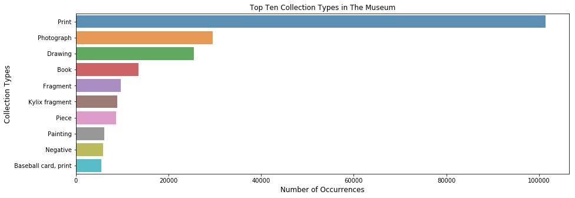

```python
plt.figure(figsize=(15,5))
sns.barplot(x = top_ten_collections.values, y = top_ten_collections.index, alpha=0.8, orient='h')
plt.title('Top Ten Collection Types in The Museum')
plt.xlabel('Number of Occurrences', fontsize=12)
plt.ylabel('Collection Types', fontsize=12)
plt.show()
```

The top amount of object type is Print. No surprise. This could be the reason for why there are so many walls in mmuseum.

### Explore the department

The Department column shows the department where each object belongs to. We are interested to take a loot at the collections of each department. And the amount of artworks in each department does not indicate which is worth visiting. We want to find the department with most highlighted artworks which are on display. Those are more worth visiting.

```python
departments = collection_df.Department.value_counts()
print(departments)
departments2 = collection_df.Department[collection_df.Is_Highlight * collection_df.Is_Public_Domain].value_counts()
print(departments2)
```

```
Drawings and Prints                          176772
European Sculpture and Decorative Arts        42976
Photographs                                   39044
Asian Art                                     37462
Greek and Roman Art                           33698
Costume Institute                             31403
Egyptian Art                                  27910
American Decorative Arts                      18568
Islamic Art                                   15784
Modern and Contemporary Art                   14802
Arms and Armor                                13579
Arts of Africa, Oceania, and the Americas     13053
Medieval Art                                   7503
Ancient Near Eastern Art                       6324
Musical Instruments                            5321
European Paintings                             2942
The Cloisters                                  2629
Robert Lehman Collection                       2586
The Libraries                                   252
Name: Department, dtype: int64
American Decorative Arts                     139
Islamic Art                                  118
Greek and Roman Art                          115
Egyptian Art                                 114
European Paintings                           103
The Libraries                                 84
Robert Lehman Collection                      81
European Sculpture and Decorative Arts        80
Musical Instruments                           79
Ancient Near Eastern Art                      75
Arts of Africa, Oceania, and the Americas     62
The Cloisters                                 58
Medieval Art                                  54
Asian Art                                     53
Arms and Armor                                53
Drawings and Prints                           51
Photographs                                   39
Costume Institute                             31
Modern and Contemporary Art                    4
Name: Department, dtype: int64
```

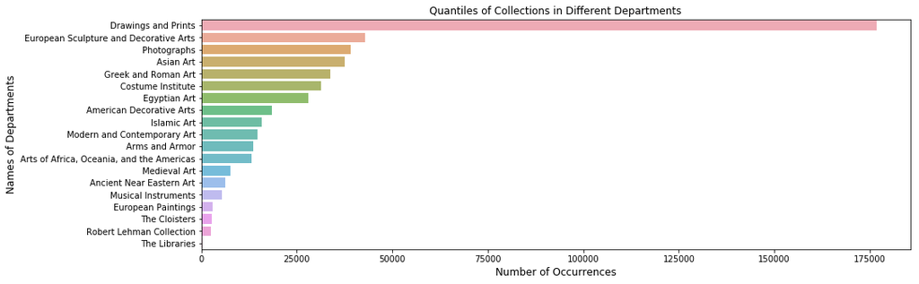

```python
plt.figure(figsize=(15,5))
sns.barplot(x = departments.values, y = departments.index, alpha=0.8, orient='h')
plt.title('Quantiles of Collections in Different Departments')
plt.xlabel('Number of Occurrences', fontsize=12)
plt.ylabel('Names of Departments', fontsize=12)
plt.show()
```

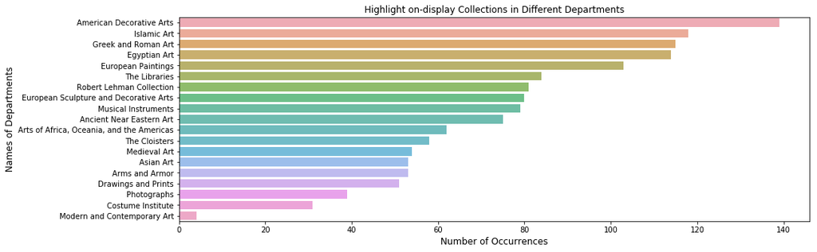

```python
plt.figure(figsize=(15,5))
sns.barplot(x = departments2.values, y = departments2.index, alpha=0.8, orient='h')
plt.title('Highlight on-display Collections in Different Departments')
plt.xlabel('Number of Occurrences', fontsize=12)
plt.ylabel('Names of Departments', fontsize=12)
plt.show()
```

The Drawing and print department has the most largbest amount of objects. However when it comes to the highlighted (famous) and on display object, it's much less than others. The American Ddecorative Arts, Islamic Art and Creek and Roman Art are the department you may find somethin well-known.

### Explore the frequency of credit line

The Credit_Year column we build in data cleaning section shows the the year of the collection been collected. We want to look at the frequency of the credit to check if the frequency increases or decreases with time flows.

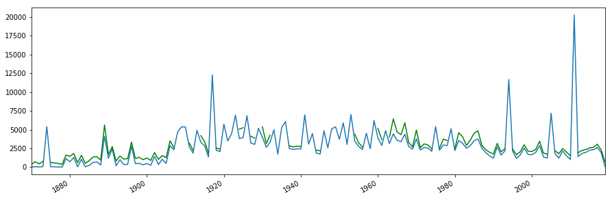

```python
freq_df = collection_df.Credit_Year.value_counts()
ax = freq_df.plot(figsize = (15,5))
freq_df.rolling(window = 30).mean().plot(ax= ax, color='green', label = 'frequnecy')
```

The amount of new coming objects per year is shown in the picture. Those peaks should be correspond to some big crediting event happend to the museum, which could be a clue to track the source of the artwork and fill missing data by the same credit line.

### Explore the most popular artist role

The Artist_Roles column is already been cleaned and reformated. We just need to extract them, count the frequency of each role and store it into a dictionary. There are too many roles, a top ten display should be enough to give some insights. Also a wordnet plot is given for vivid check.

```python
def select_top_ten_roles(df):
    roles = defaultdict(int)
    for i in df[df.Artist_Role.notna()].index:
        for role in df.Artist_Role.loc[i].split('|'):
            roles[role] += 1
    x, y = [], []
    upper_bound = inf
    for _ in range(10):
        lar = -inf
        for key,val in roles.items():
            if lar < val < upper_bound:
                lar = val
                temp = key
        upper_bound = lar
        x.append(lar)
        y.append(temp)
    return x, y, roles
x, y, roles = select_top_ten_roles(collection_df)
```

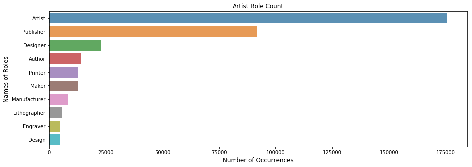

```python
plt.figure(figsize=(15,5))
sns.barplot(x = x, y = y, alpha=0.8, orient='h')
plt.title('Artist Role Count')
plt.xlabel('Number of Occurrences', fontsize=12)
plt.ylabel('Names of Roles', fontsize=12)
plt.show()
```

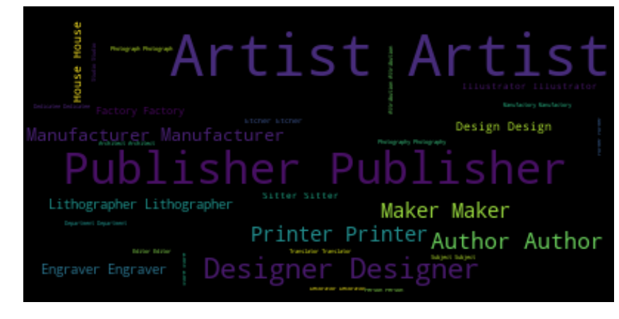

```python
text = ''
for key in roles:
    text += (key+' ')*roles[key]
# text = " ".join(words)
wordcloud = WordCloud().generate(text)
plt.figure(figsize=(15,10))
plt.imshow(wordcloud, interpolation='bilinear',)
plt.axis("off")
plt.show()
```

If someone chooses to become an artist, this is an suggestion of which roles are better to choose that may more likely to make a masterpiece in general.

## Conclusion

**Main Feature**: In this project we are focused on how to clean string data, extract informations from the data bu using regex and NLP. The natural way to analyze the cleaned str data is to count the frequency by category. We tried visualize the frequency both by category and by timeline.

**Summary**: The whole project should give others a general look of how the artworks in The Metropolitan Museum of Art distributed with different scales.

**Future work**: A further deep analysis could be implemented on the credit year timeline to check if there is any event could be connected with the peak or valley of the credit line frequency. Or we can build a network between the Metropolitan Museum of Art and other museums to see the artworks' flow pattern.